# EJERCICIOS_RESUELTOS

Pierina Isabel Tuanama Satalaya

1/7/2021

# EJERCICIOS

## Parte 1

**1. Calcula los valores numèricos aproximados de:**

1. $\frac{0.3 \cdot 0.15}{0.3 \cdot 0.15 + 0.2 \cdot 0.8 + 0.5 \cdot 0.12}$

```r
a_1 <- (0.3*0.15)
a <- a_1/(a_1 + (0.2*0.8) + (0.5*0.12))
a
```

```
## [1] 0.1698113
```

2. $\frac{5^6}{6!} e^{-5}$

```r
b_1 <- (5^6)
b_2 <- factorial(6)
b_3 <- exp(-5)
b   <- (b_1/b_2)*b_3
b
```

```
## [1] 0.1462228
```

3. $\begin{pmatrix} 20 \\ 7 \end{pmatrix} 0.4^7 0.6^{13}$

```r
c <- choose(20,7)*(0.4^7)*(0.6)^13
c
```

```
## [1] 0.1658823
```

**2. Realizar la siguiente suma**

1. $1+2+3+...+1000$

```r
sum(1:1000)
```

```
## [1] 500500
```

2. $1+2+4+8+16+...+1024$

```r
sum(2^(0:10))
```

```
## [1] 2047
```

**3. El vector `grupo` representa el grupo al que pertenece una serie de alumnos**

Para desarrollar los siguientes ejercios debemos cargar las variables almacenadas en el siguiente archivo [Rdata](https://goo.gl/uDzU8v)

```r
load("ei1012-1516-la-s1-datos.RData")
```

1. ¿Cuántos elementos tiene?

```r
length(grupo)
```

```
## [1] 192
```

2. ¿En qué posiciones del vector está la letra “A”?

```r
which(grupo == "A")
```

```
##  [1]   2   8  17  21  28  84 101 108 111 115 123 136 190 192
```

**4. El vector `nota` representa la nota de un examen de los alumnos que están en los grupos del vector `grupo`.**

1. ¿Cuanto suman todas las notas?

```r
sum(nota)
```

```
## [1] 962
```

2. ¿Cual es la media aritmética de todas las notas?

```r
mean(nota)
```

```
## [1] 5.010417
```

3. ¿En qué posiciones están las notas mayores de *7.0*?

```r
which(nota > 7)
```

```
## [1]  81 103 120 151
```

4. Visualiza las notas ordenadas de mayor a menor

```r
nota_d <- sort(nota, decreasing = T)
head(nota_d)
```

```
## [1] 7.7 7.5 7.4 7.2 7.0 6.9
```

5. ¿En qué posición está la nota máxima?

```r
which(nota == max(nota))
```

```
## [1] 120
```

**5. A partir de los vectores `grupo` y `nota` definidos.**

```r
library(tidyverse)
nota_grupo <- data.frame(grupo,nota)
head(nota_grupo)
```

```
##   grupo nota
## 1     B  4.9
## 2     A  5.4
## 3     E  5.2
## 4     D  6.8
## 5     B  5.0
## 6     D  6.2
```

1. Suma las notas de los 10 primeros alumnos del vector

```r
a_5 <-sum(nota_grupo$nota[1:10])
a_5
```

```
## [1] 51.8
```

2. ¿Cuántos alumnos hay del grupo *C*?

```r
b_5 <- subset(nota_grupo, grupo =="C")
count(b_5)
```

```
##    n
## 1 39
```

3. ¿Cuántos alumnos han aprobado?

```r
c_5 <- count(subset(nota_grupo , nota > 5))
c_5
```

```
##    n
## 1 93
```

4. ¿Cuántos alumnos del grupo *B* han aprobado?

```r
d_5 <- subset(nota_grupo, grupo == "B" & nota > 5 )
d_5
```

```
##     grupo nota
## 13      B  6.4
## 18      B  6.4
## 65      B  5.5
## 86      B  5.8
## 103     B  7.4
## 148     B  6.0
## 170     B  5.9
## 176     B  6.8
## 186     B  5.4
## 187     B  5.9
```

```r
count(d_5)
```

```
##    n
## 1 10
```

5. ¿Qué porcentaje de alumnos del grupo *C* han aprobado?

```r
aproC <- subset(nota_grupo, grupo =="C"& nota > 5)
e_5 <- (count(aproC)/count(b_5))*100
e_5
```

```
##          n
## 1 56.41026
```

```r
max(nota[grupo == "A"])
```

```
## [1] 5.6
```

7. Nota media de los alumnos de grupo *A* y *B*, juntos, considerando sólo a los que han aprobado.

```r
g_1 <- nota[ grupo=='A' & nota >5]
g_2 <- nota[ grupo=='B' & nota >5]
g_3 <- c(g_1,g_2)
g <- round(mean(g_3),3)
g
```

```
## [1] 5.943
```

**6. Calcula el percentil 66 de las notas de todos los alumnos, y también de los alumnos del grupo C.**

```r
per66 <- quantile(nota,0.66)
per66
```

```
## 66%
## 5.5
```

```r
quantile(nota[ grupo=="C"] , 0.66)
```

```
##   66%
## 5.808
```

**7. Un alumno tiene una nota de 4.9. ¿Qué porcentaje, del total de alumnos, tiene una nota menor o igual que la suya? ¿Y qué porcentaje tiene una nota mayor o igual que la suya?**

```r
por_c <-subset(nota_grupo, nota >=4.9)
(count(por_c)/count(nota_grupo))*100
```

```
##       n
## 1 56.25
```

```r
por_cmn <-subset(nota_grupo, nota <=4.9)
(count(por_cmn)/count(nota_grupo))*100
```

```
##        n
## 1 46.875
```

**8. Realiza el gráfico de diagramas de caja de las notas de cada grupo, para poder comparar el nivel de cada uno de ellos.**

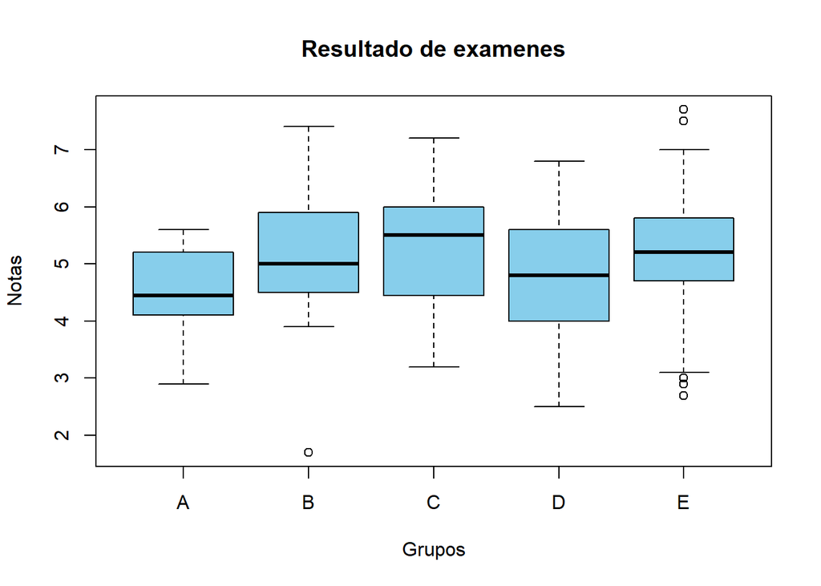

```r
boxplot(nota_grupo$nota ~ nota_grupo$grupo,
        col = "skyblue",
        labels = T,
        xlab = "Grupos",
        ylab = "Notas",
        main = "Resultado de examenes")
```

**9. Si la variable `conc` recoge la concentración de plomo (en ppm) en el aire de cierta zona durante un día completo**

1. ¿Cuál ha sido la concentración máxima?

```r
max(conc)
```

```
## [1] 47.34
```

2. ¿En cuántos de los muestreos se ha superado la concentración de 40.0 ppm?

```r
which(conc > 40) %>%  length()
```

```
## [1] 61
```

3. ¿Cuál ha sido la concentración media del día?

```r
mean(conc)
```

```
## [1] 24.07229
```

4. ¿Cuáles fueron las 10 mediciones más bajas del día?

```r
conc1 <- sort(conc)
conc1[1:10]
```

```
##  [1] 0.93 1.07 1.77 2.03 2.58 2.73 2.75 2.88 2.88 2.91
```

5. Si la primera medida fue a las 00:00. ¿A qué hora del día se alcanzó la concentración máxima?

```r
# Creamos una secuencia de datos de fecha con inicio en la hora pedida:
date1 <- seq(
  as.POSIXct("2021-01-01 00:00"),
  length.out = length(conc),
  by = "5 min"
)

#Creamos un data frame con los datos de concentracion de plomo y las fechas
df03 <- data.frame(conc, date1)

#Consultamos cual es el valor maximo de concentracion y a su vez nos trae el dato de la hora en que fue tomada
df03[conc == max(conc),]
```

```
##      conc               date1
## 142 47.34 2021-01-01 11:45:00
```

## Parte 2

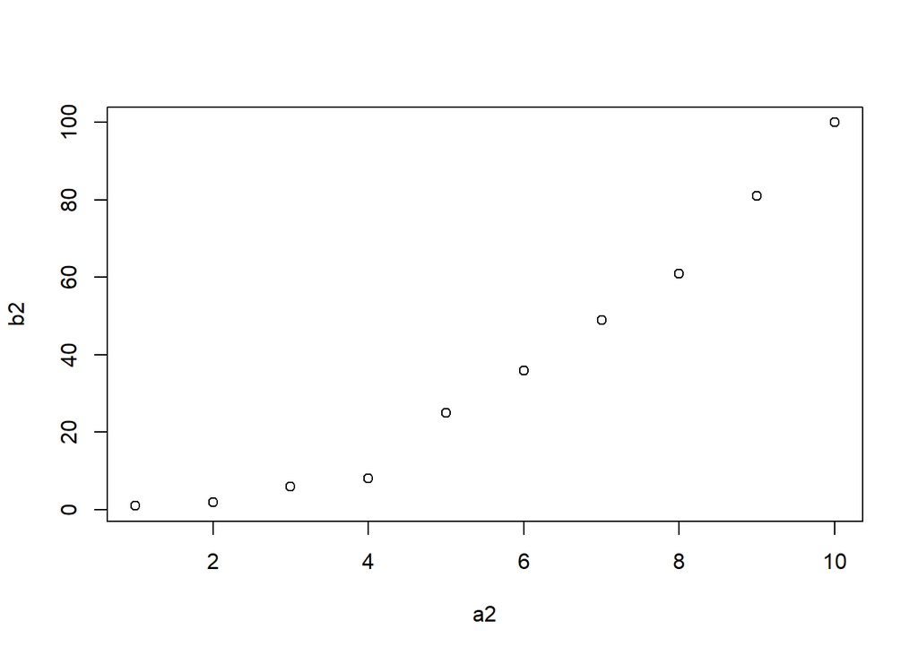

```r
a2 <- c(1:10)
b2 <- c(1,2,6,8,25,36,49,61,81,100)
plot(a2,b2)
```

**2. Ingresar la matriz A en RStudio** $A = \begin{pmatrix} 1 & 2 & 3 \\ 2 & 4 & 6 \\ 3 & 6 & 9 \\ 4 & 8 & 12 \end{pmatrix}$

```r
a21 <- c(1:4)
a22 <- a21*2
a23 <- a21*3
a24 <- c(a21,a22,a23)
A <- matrix( a24 ,nrow=4 , ncol =3)
A
```

```
##      [,1] [,2] [,3]
## [1,]    1    2    3
## [2,]    2    4    6
## [3,]    3    6    9
## [4,]    4    8   12
```

```r
Id <- diag(1, nrow=3)
I <-Id*3
I
```

```
##      [,1] [,2] [,3]
## [1,]    3    0    0
## [2,]    0    3    0
## [3,]    0    0    3
```

**4. Crea una función que cree una matriz nula ingresando las dimensiones**

```r
mnula <-  function(a,b){
  matrix(0, nrow = a , ncol=b)
}
mnula(4,4)
```

```
##      [,1] [,2] [,3] [,4]
## [1,]    0    0    0    0
## [2,]    0    0    0    0
## [3,]    0    0    0    0
## [4,]    0    0    0    0
```

**5. Modificar la matriz `diag(4)`, para que se parezca a la matriz B** $B = \begin{pmatrix} 0 & 0 & 0 & 0 \\ 0 & 2 & 0 & 0 \\ 0 & 0 & 3 & 0 \\ 0 & 0 & 0 & 4 \end{pmatrix}$

```r
B <- mnula(4,4)
B[1,1]=0
B[2,2]=2
B[3,3]=3
B[4,4]=4
B
```

```
##      [,1] [,2] [,3] [,4]
## [1,]    0    0    0    0
## [2,]    0    2    0    0
## [3,]    0    0    3    0
## [4,]    0    0    0    4
```

**6. Obtener la matriz transpuesta de A (ejercicio 2)**

```r
t(A)
```

```
##      [,1] [,2] [,3] [,4]
## [1,]    1    2    3    4
## [2,]    2    4    6    8
## [3,]    3    6    9   12
```

```r
# dichas opraciones no se pueden realizar ya que las dimensiones de las matrices
# son diferentes
#A+B
#A-B
#A*B
3*A
```

```
##      [,1] [,2] [,3]
## [1,]    3    6    9
## [2,]    6   12   18
## [3,]    9   18   27
## [4,]   12   24   36
```

**8. Crea una función para calcular $P^6$** $P = \begin{pmatrix} 1 & 2 & 3 \\ -2 & 4 & -2 \\ 1 & 0 & 1 \end{pmatrix}$

```r
p8 <- function(M,a){
  b= M ;
  for(i in 2:a){
    b = b %*% M}
  print(b)
}
P <- matrix(c(1,2,3,-2,4,-2,1,0,1),3,3, by = T)
p8(P,6)
```

```
##       [,1]  [,2]  [,3]
## [1,] -1792    24 -2824
## [2,]  -464 -2416 -1344
## [3,]  -648   440  -912
```

**9. Resolver el sistema de ecuaciones** $3x - y + z = -1\\9x - 2y + z = -9\\3x + y - 2z = -9$

```r
k<- matrix(c(3,9,3,-1,-2,1,1,1,-2), ncol=3,nrow=3)
l <-c(-1,-9,-9)
solve(k,l)
```

```
## [1] -1  2  4
```

**10. Utilizando la ayuda de R, investigue para qué sirven las funciones `eigen()` y `det()`**

**11. Considerando las matrices**

B=
$$\begin{pmatrix}
1 & 2 & 3 & 4 & 5 \\
2 & 4 & 6 & 8 & 10 \\
3 & 6 & 9 & 12 & 15 \\
4 & 8 & 12 & 16 & 20 \\
5 & 10 & 15 & 20 & 25 \\
6 & 12 & 18 & 24 & 30 \\
7 & 14 & 21 & 28 & 35 \\
8 & 16 & 24 & 32 & 40 \\
9 & 18 & 27 & 36 & 45 \\
10 & 20 & 30 & 40 & 50
\end{pmatrix}$$
A =
$$\begin{pmatrix}
0 & 1 & 0 & 1 & 0 \\
1 & 0 & 1 & 0 & 1 \\
0 & 1 & 0 & 1 & 0 \\
0 & 1 & 0 & 0 & 1 \\
1 & 0 & 1 & 1 & 0 \\
\end{pmatrix}$$

```r
x  <- c(0,1)
x1 <-rep(x,7)
y  <- c(0,0,1)
y1 <-rep(y,2)
A <- matrix(c(x1,y1,1,0,1,1,0), ncol=5,nrow = 5 , by = T)
A
```

```
##      [,1] [,2] [,3] [,4] [,5]
## [1,]    0    1    0    1    0
## [2,]    1    0    1    0    1
## [3,]    0    1    0    1    0
## [4,]    0    1    0    0    1
## [5,]    1    0    1    1    0
```

```r
a <- c(1:10)
b <- a*2
c <- a*3
d <- a*4
e <- a*5
f <- c(a,b,c,d,e)
B <- matrix(f, 5 ,10 )

Bt <- t(B)
Bt
```

```
##       [,1] [,2] [,3] [,4] [,5]
##  [1,]    1    2    3    4    5
##  [2,]    6    7    8    9   10
##  [3,]    2    4    6    8   10
##  [4,]   12   14   16   18   20
##  [5,]    3    6    9   12   15
##  [6,]   18   21   24   27   30
##  [7,]    4    8   12   16   20
##  [8,]   24   28   32   36   40
##  [9,]    5   10   15   20   25
## [10,]   30   35   40   45   50
```

**12. Considere** $\hat\beta = (X^t \cdot X)^{-1} \cdot X^t \cdot Y$

x=
$$\begin{pmatrix}1 & 1\\ 1 & -1\\ 1 & 0\\ 1 & 1\\ 1 & 2\\ \end{pmatrix}$$
y =
$$\begin{pmatrix}0\\0\\1\\1\\3\\\end{pmatrix}$$

```r
x2 <- c(rep(1,5),1,-1,0,1,2)
x  <- matrix(x2, 5,2)
x
```

```
##      [,1] [,2]
## [1,]    1    1
## [2,]    1   -1
## [3,]    1    0
## [4,]    1    1
## [5,]    1    2
```

```r
y <- matrix(c(rep(0,2), rep(1,2) , 3))
y
```

```
##      [,1]
## [1,]    0
## [2,]    0
## [3,]    1
## [4,]    1
## [5,]    3
```

**13. Corre el siguiente código para cargar los vectores `year` y `co2`**

```r
data(co2)
means = aggregate(co2, FUN=mean)
year = as.vector(time(means))
co2 = as.vector(means)
```

- El vector `co2` contiene medidas de $CO_2$ en la atmósfera, en unidades de *ppm*, durante el periodo 1959-1997. El vector `year` contiene sus años correspondientes.
- Calcular un vector de diferencias de $CO_2$ entre años consecutivos, que sería:
  - $CO_2$ en 1960 menos $CO_2$ en 1959
  - $CO_2$ en 1961 menos $CO_2$ en 1960
  - y así sucesivamente…

```r
df_co2 <- data.frame(year = year, co2 = co2) %>%
  mutate(co2_2 = lag(co2), dif_co2 = co2 - co2_2)
vect_diferencia <- df_co2$dif_co2[2:39]
vect_diferencia
```

```
##  [1] 0.9216667 0.7375000 0.8125000 0.5350000 0.6300000 0.4100000 1.3375000
##  [8] 0.8100000 0.8700000 1.5691667 1.0583333 0.6375000 1.1383333 2.2183333
## [15] 0.5675000 0.9066667 1.0000000 1.7441667 1.6058333 1.3450000 1.8341667
## [22] 1.2458333 1.1983333 1.6491667 1.6383333 1.4791667 1.2491667 1.7758333
## [29] 2.5625000 1.4408333 1.2825000 1.4416667 0.8133333 0.7041667 1.8841667
## [36] 2.0341667 1.7725000 1.1308333
```

- Crear un **plot** con lineas y puntos mostrando las diferencias consecutivas de $CO_2$ en función del tiempo (1960, 1961, etc…), en **negrita**
- La diferencia de concentración de $CO_2$ entre 2020 y 2019 fue igual a 2.64. Agregar un punto rojo representando esa diferencia al plot ya creado (usar una forma diferente, como `pch=4`)

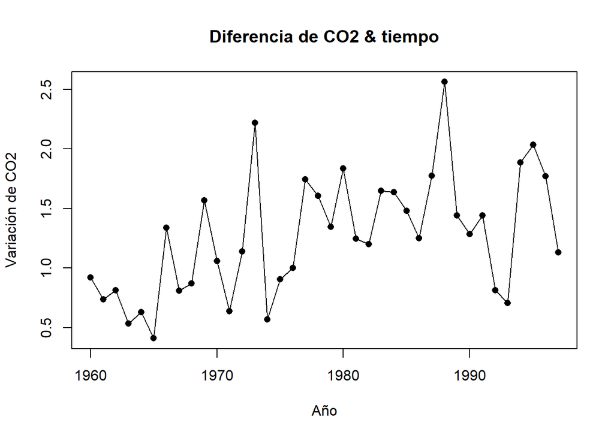

```r
plot(x = df_co2$year[2:39], y = vect_diferencia, xlab = "Año", ylab = "Variación de CO2",
     main = "Diferencia de CO2 & tiempo", type = "o", pch = 16)
```

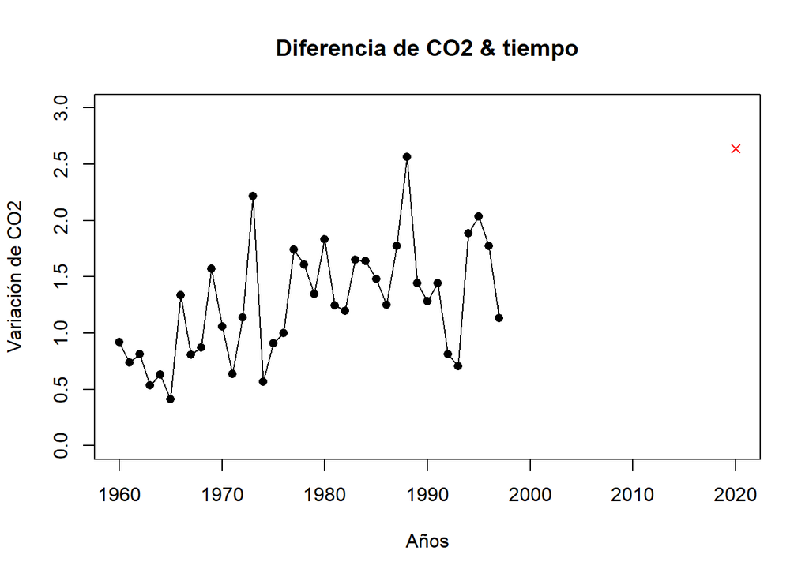

```r
plot(x = df_co2$year[2:39], y = vect_diferencia, xlab = "Años", ylab = "Variación de CO2",
     main = "Diferencia de CO2 & tiempo", type = "o", pch = 16, xlim = c(1960,2020),
     ylim = c(0,3))
points(2020, 2.64, pch = 4, col = "red")
```

**14.**